# 分析数据

先导入各种需要的库

```python
import os
import warnings
import gc
import multiprocessing as mp
import pandas as pd
import numpy as np
import seaborn as sns
import matplotlib.pyplot as plt
from tqdm import tqdm_notebook
from sklearn.linear_model import LinearRegression
import scipy.signal as sg
from scipy.stats import pearsonr
from scipy.signal import hilbert, convolve, hann
from scipy import stats
from tsfresh.feature_extraction import feature_calculators
from sklearn.preprocessing import StandardScaler
from sklearn.model_selection import KFold
from sklearn.metrics import mean_absolute_error
from tensorflow import keras
from sklearn.svm import NuSVR
import lightgbm as lgb
import xgboost as xgb
import catboost as cb
from hyperopt import hp, tpe, Trials, STATUS_OK
from hyperopt.fmin import fmin
warnings.filterwarnings("ignore")
```

## 载入数据

```python
PATH = '../input/LANL-Earthquake-Prediction' # 数据路径
os.listdir(PATH)
```

```
['sample_submission.csv', 'test', 'train.csv']
```

```python
%%time

train_data = pd.read_csv(os.path.join(PATH, 'train.csv'),
                            dtype={'acoustic_data': np.int16, 'time_to_failure': np.float32})
```

```
CPU times: user 2min 6s, sys: 10.5 s, total: 2min 17s
Wall time: 2min 17s
```

## 分析数据

看看数据集有多大：

```python
print('Train: rows:{} cols:{}'.format(train_data.shape[0], train_data.shape[1]))
```

```
Train: rows:629145480 cols:2
```

然后看看数据有没有缺失值：

```python
train_data.isnull().any()
```

```
acoustic_data      False
time_to_failure    False
dtype: bool
```

看起来没有缺失值，不需要对缺失值进行处理。  
取前十条数据，看看数据有哪些信息：

```python
train_data.head(10)
```

|  | acoustic_data | time_to_failure |
| --- | --- | --- |
| 0 | 12 | 1.4691 |
| 1 | 6 | 1.4691 |
| 2 | 8 | 1.4691 |
| 3 | 5 | 1.4691 |
| 4 | 8 | 1.4691 |
| 5 | 8 | 1.4691 |
| 6 | 9 | 1.4691 |
| 7 | 7 | 1.4691 |
| 8 | -5 | 1.4691 |
| 9 | 3 | 1.4691 |

接下来，对数据做一个大致的分布查看（由于数据量太大——6亿条，所以通过采样取其中1%查看）：

```
49
```

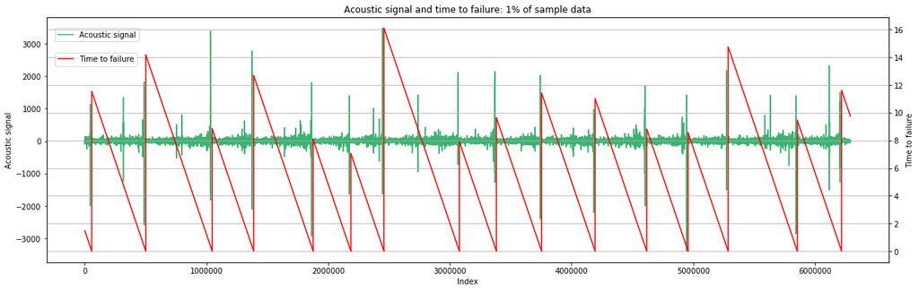

```python
train_ad_sample = train_data['acoustic_data'].values[::100]
train_ttf_sample = train_data['time_to_failure'].values[::100]

def plot_ad_ttf_data(plot1, plot2, title = "Acoustic signal and time to failure: 1% of sample data"):
    fig, ax1 = plt.subplots(figsize=(20, 6))
    ax1.plot(plot1, color='mediumseagreen')
    ax1.set_title(title)
    ax1.set_xlabel('Index')
    ax1.set_ylabel('Acoustic signal')
    ax1.legend(['Acoustic signal'], loc=(0.01, 0.9))
    ax2 = ax1.twinx()
    ax2.plot(plot2, color='Red')
    ax2.set_ylabel('Time to failure')
    ax2.legend(['Time to failure'], loc=(0.01, 0.8))
    ax2.grid()

plot_ad_ttf_data(train_ad_sample, train_ttf_sample)

del train_ad_sample
del train_ttf_sample
gc.collect()
```

为更好地观察声学数据和地震来临时间的关系，取能包含第一次地震的数据（整个数据的钱1%，不进行采样）观察：

```
4903
```

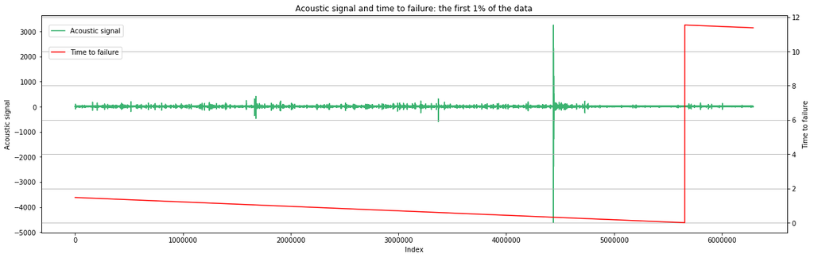

```python
train_ad_part = train_data['acoustic_data'].values[:6291454]
train_ttf_part = train_data['time_to_failure'].values[:6291454]
plot_ad_ttf_data(train_ad_part, train_ttf_part, title="Acoustic signal and time to failure: the first 1% of the data")
del train_ad_part
del train_ttf_part
gc.collect()
```

```
4911
```

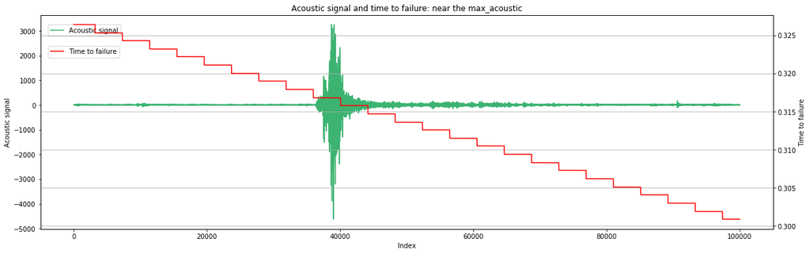

```python
train_ad_max = train_data['acoustic_data'].values[4400000:4500000]
train_ttf_max = train_data['time_to_failure'].values[4400000:4500000]
plot_ad_ttf_data(train_ad_max, train_ttf_max, title="Acoustic signal and time to failure: near the max_acoustic")
del train_ad_max
del train_ttf_max
gc.collect()
```

上图证实了前1%图和采样图在第一次地震到来前声学信号极大值的偏差是由于采样只取到了一部分数据造成的。  
观察最大声学信号附近的图得到以下信息：  
（1）'time_to_failure'不是像前1%图中看到的那样是均匀下降的，而是每一段都很平缓，隔大约4000个数据出现一次较大的下降  
（2）较大声学震动来临之前声学数据已经逐渐趋向平缓，而来临后又出现持续震动。  
（3）较大声学震动后再经过约0.31秒地震来临。  
取第二次地震来临的数据，验证上述三个结论是偶然还是必然：

```
4703
```

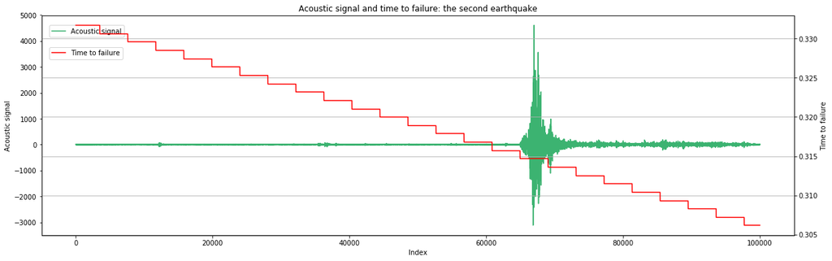

```python
train_ad_part = train_data['acoustic_data'].values[103400000:103500000]
train_ttf_part = train_data['time_to_failure'].values[103400000:103500000]
plot_ad_ttf_data(train_ad_part, train_ttf_part, title="Acoustic signal and time to failure: the second earthquake")
del train_ad_part
del train_ttf_part
gc.collect()
```

三个结论完全和第一次地震一致。另外，对第一次地震还有一点需要探索：大声学信号来临前后地震来临的时间是否有变化：

```
4644
```

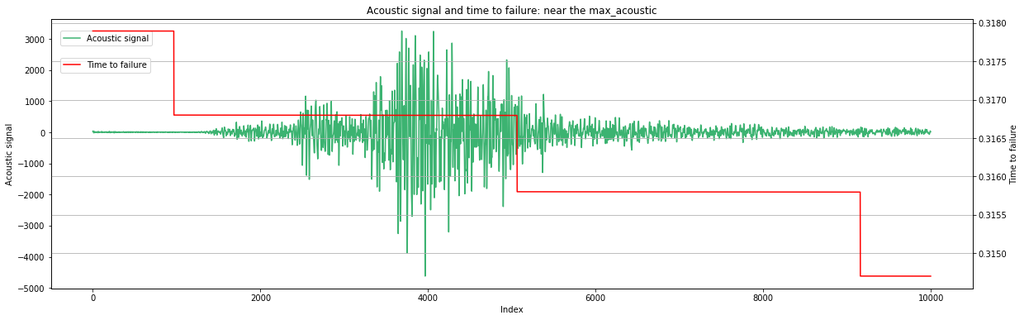

```python
train_ad_max = train_data['acoustic_data'].values[4435000:4445000]
train_ttf_max = train_data['time_to_failure'].values[4435000:4445000]
plot_ad_ttf_data(train_ad_max, train_ttf_max, title="Acoustic signal and time to failure: near the max_acoustic")
del train_ad_max
del train_ttf_max
gc.collect()
```

发现大声学数据对'time_to_failure'的变化没有影响。另外：“平缓”阶段声学数据在-50~50之间变化。  
还有一点要查看的——地震来临时刻附近的数据：

```
4779
```

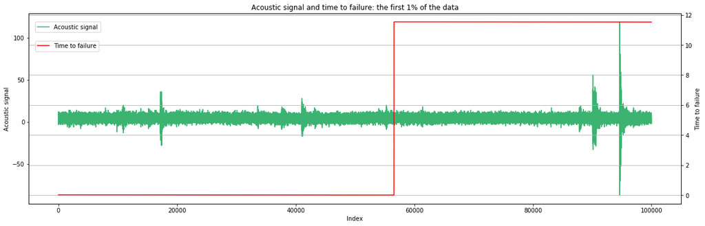

```python
train_ad_part = train_data['acoustic_data'].values[5600000:5700000]
train_ttf_part = train_data['time_to_failure'].values[5600000:5700000]
plot_ad_ttf_data(train_ad_part, train_ttf_part, title="Acoustic signal and time to failure: the first 1% of the data")
del train_ad_part
del train_ttf_part
gc.collect()
```

此外，我们还注意到，有的时候有大声学信号，却没有地震到来，这些地方也需要观察一下：

```
4464
```

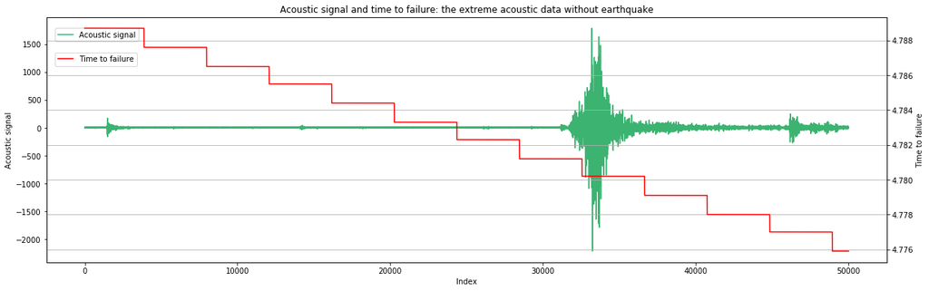

```python
train_ad_part = train_data['acoustic_data'].values[31650000:31700000]
train_ttf_part = train_data['time_to_failure'].values[31650000:31700000]
plot_ad_ttf_data(train_ad_part, train_ttf_part, title="Acoustic signal and time to failure: the extreme acoustic data without earthquake")
del train_ad_part
del train_ttf_part
gc.collect()
```

该信号与地震信号极其相似，但没有地震到来。当然，这个极大信号没有地震到来的时候大。为了验证是否噪声信号都没有地震信号大，取第一幅图中看起来最小的地震信号和最大的噪声信号

```
10
```

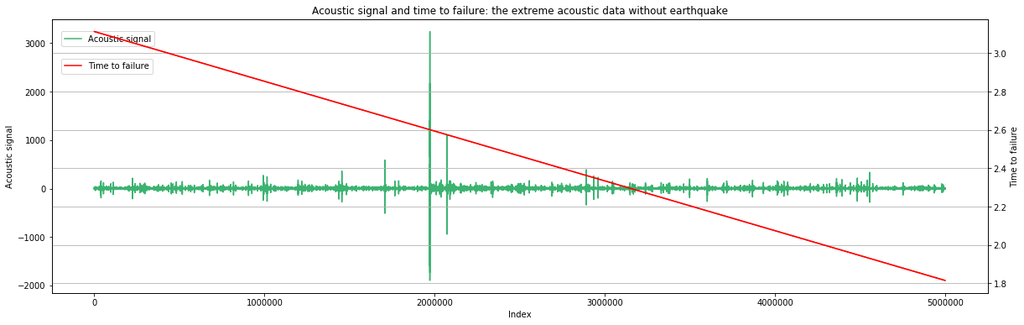

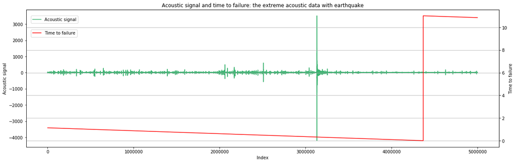

```python
train_ad_part = train_data['acoustic_data'].values[610000000:615000000]
train_ttf_part = train_data['time_to_failure'].values[610000000:615000000]
plot_ad_ttf_data(train_ad_part, train_ttf_part, title="Acoustic signal and time to failure: the extreme acoustic data without earthquake")
del train_ad_part
del train_ttf_part
gc.collect()

train_ad_part = train_data['acoustic_data'].values[415000000:420000000]
train_ttf_part = train_data['time_to_failure'].values[415000000:420000000]
plot_ad_ttf_data(train_ad_part, train_ttf_part, title="Acoustic signal and time to failure: the extreme acoustic data with earthquake")
del train_ad_part
del train_ttf_part
gc.collect()
```

二者非常接近，很难分辨是地震还是噪声。在后续处理中需要考虑怎么去除这些噪声。

接下来查看测试数据长什么样：

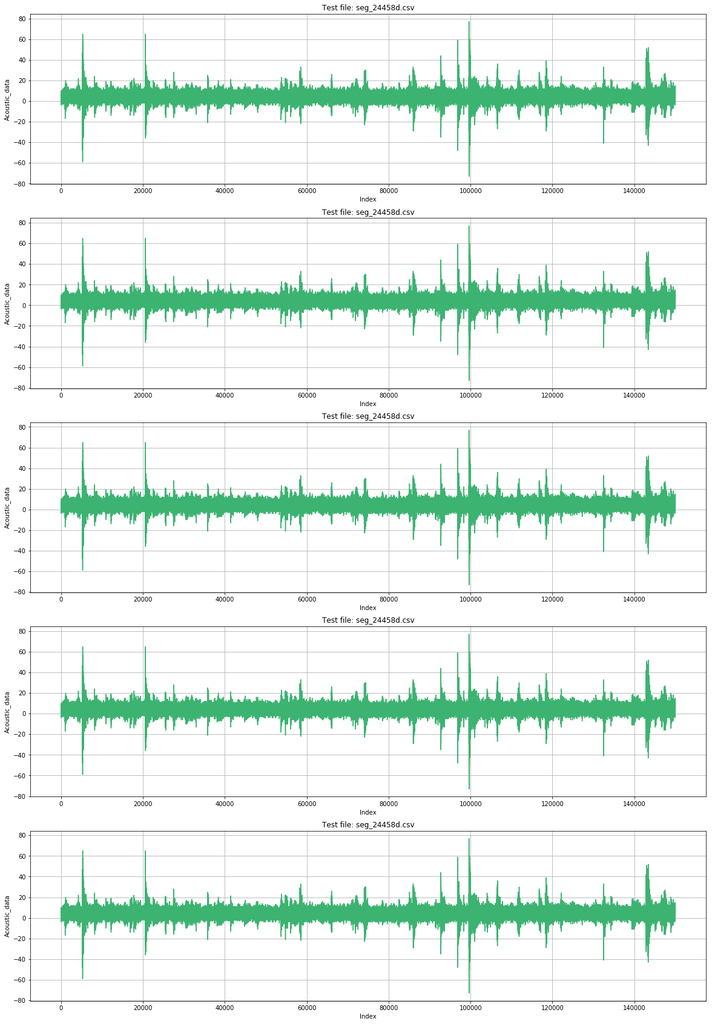

```python
TEST_PATH = PATH + '/test'
test_files = os.listdir(TEST_PATH)
fig, ax = plt.subplots(5, 1, figsize=(20, 30))
for i in range(5):
    np.random.seed(5)
    test_file_index = np.random.choice(list(range(len(test_files))))
    test_file = pd.read_csv(os.path.join(TEST_PATH, test_files[test_file_index]),
                           dtype={'acoustic_data': np.int16})
    ax[i].plot(test_file['acoustic_data'], color='mediumseagreen')
    ax[i].set_xlabel('Index')
    ax[i].set_ylabel('Acoustic_data')
    ax[i].set_title('Test file: {}'.format(test_files[test_file_index]))
    ax[i].grid()
```

```python
peaks = np.zeros(len(test_files))
base_len = len(pd.read_csv(os.path.join(PATH, 'test', test_files[0])))
for i, test_file in enumerate(test_files):
    test_signal = pd.read_csv(os.path.join(PATH, 'test', test_file))
    test_len = len(test_signal)
    if test_len != base_len:
        print("Not all the test files equilong.")
        break
    if i == len(test_files)-1:
        print("The length of all the test files are {}".format(base_len))
    peaks[i] = test_signal.abs().max()
```

```
The length of all the test files are 150000
```

根据对训练数据的观察，我们可以认为一段信号的峰值大于2000，那他就应该是一段地震信号。

```python
acoustic_peaks = peaks[peaks>2000]
print("The test files happens {} earthquake".format(len(acoustic_peaks)))
```

```
The test files happens 10 earthquake
```

训练数据如果按照预测数据的长度（150000）进行切分，将得到4194段信号，这4194段信号中有16次地震发生；测试数据有2624段信号，其中有10次地震发生，刚好对应。  
在频域对信号进行分析，观察特点：

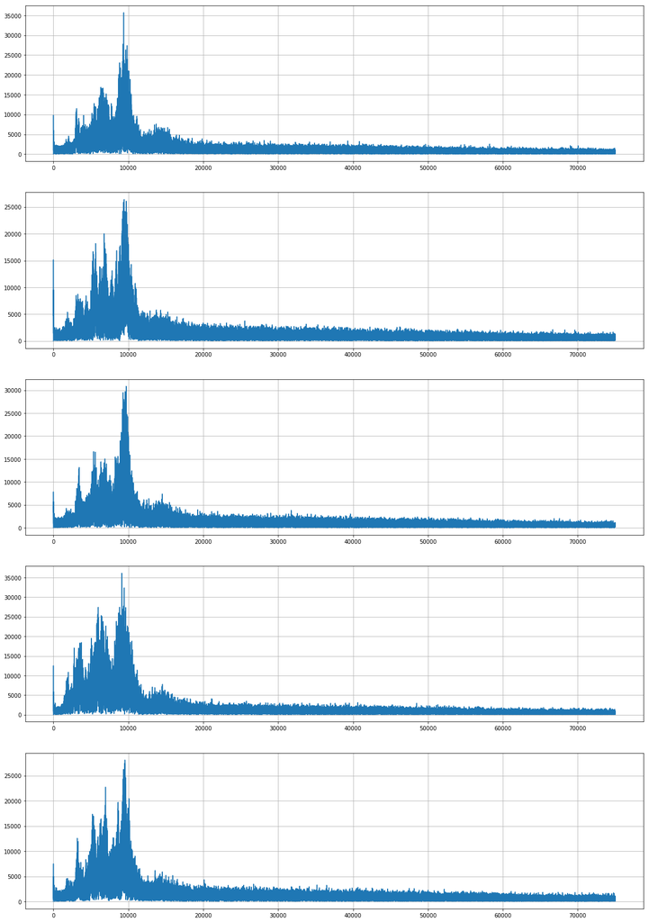

```python
fig, ax = plt.subplots(5, 1, figsize=(20, 6*5))
for i, test_file in enumerate(test_files[:5]):
    test_signal = pd.read_csv(os.path.join(PATH, 'test', test_file))
    ad = test_signal['acoustic_data'].values
    ad = ad - np.mean(ad) # 将均值归零以去除信号中的直流分量，否则除直流分量外的信号在图像中难以体现
#     b, a = sg.butter(6, Wn=20000/75000)
#     ad = sg.lfilter(b, a, ad)
    zc = np.fft.fft(ad)
    zc = zc[:75000] # 由于频谱图是对称的，根据奈奎斯特频率只显示一半
    realFFT = np.real(zc)
    imagFFT = np.imag(zc)
    magFFT = np.sqrt(realFFT**2 + imagFFT**2)
    ax[i].plot(magFFT)
    ax[i].grid()
```

可以看出，信号主要集中在低频区域，当频率高于20000的时候，信号量就逐渐减少，这些区域可能是噪声，在进行特征工程时要通过预处理去除。  
最后，看一下训练数据的分布：

```python
def describe_data(data):
    total_mean = data['acoustic_data'].mean()
    print("Total mean:", total_mean)
    total_std = data['acoustic_data'].std()
    print("Total std:", total_std)
    total_min = data['acoustic_data'].min()
    print("Total min:", total_min)
    total_max = data['acoustic_data'].max()
    print("Total max:", total_max)
    total_q50 = data['acoustic_data'].quantile(0.5)
    print("Total q50:", total_q50)
    total_sum = data['acoustic_data'].sum()
    print("Total sum:", total_sum)
    total_abs_sum = np.abs(data['acoustic_data']).sum()
    print("Total abs sum:", total_abs_sum)


# describe_data(train_data)
```

# 特征工程

## 处理训练集

每条测试数据的长度是150000，将训练数据也按照这个长度进行划分。

```python
signal_len = 150000
num_segments = int(train_data.shape[0]/signal_len)
print("Number of segments: ", num_segments)
```

```
Number of segments:  4194
```

可以看到，如果进行无重复分割，将得到4194条数据。但原始的6亿多条数据每条数据都有对应的标签，无重复分割对标签的利用率太低，所以考虑进行有重复分割。但有重复分割存在另一个问题：数据和数据之间有重叠，那就存在信息泄露，导致有可能即便算法效果很差，对训练集也能拟合得很好。  
针对这个问题，经过实验后，将训练集样本数确定在24000。  
首先将原始数据分成6份，这样能保证这6份数据之间不存在信息泄露，同时可以利用多线程处理数据。

```python
num_processes = 6
def split_raw_data(train_data):
    for i in range(num_processes):
        split_data_len = int(len(train_data.index) / num_processes)
        df = train_data.iloc[split_data_len*i: split_data_len*(i+1)]
        df.to_csv(os.path.join(PATH, 'train_%d.csv' % i), index=False)
        del df

# split_raw_data(train_data)
```

在分段后的数据中随机选取一段数据，从而减小数据泄露的影响。为此，首先建立选取数据的start_index。

```python
num_seg_per_process = 4000
def set_start_indices():
    split_data_len = int(len(train_data.index) / num_processes) - signal_len
    rnd_idx_mat = np.zeros((num_seg_per_process, num_processes))
    for i in range(num_processes):
        np.random.seed(i**2)
        start_indices = np.random.randint(0, split_data_len, size=num_seg_per_process, dtype=np.int32)
        rnd_idx_mat[:, i] = start_indices
    np.savetxt(os.path.join(INPUT_DIR, 'start_indices_matrix.csv'), rnd_idx_mat, fmt='%d',delimiter=',')

# set_start_indices()
```

定义训练集：

```python
train_X = pd.DataFrame(dtype=np.float64)
train_y = pd.DataFrame(dtype=np.float64, columns=['time_to_failure'])
```

创建特征需要用到的函数：

```python
nyquist_freq = 75000 # 奈奎斯特频率——最高频率的一半
max_freq = 20000 # 超过20000的几乎都是噪声
freq_step = 2500 # 带通滤波通过宽度

def des_bw_filter_lp(cutoff):
    """4阶巴特沃斯低通滤波器"""
    b, a = sg.butter(4, Wn=cutoff/nyquist_freq, btype='lowpass')
    return b, a

def des_bw_filter_hp(cutoff):
    """4阶巴特沃斯高通滤波器"""
    b, a = sg.butter(4, Wn=cutoff/nyquist_freq, btype='highpass')
    return b, a

def des_bw_filter_bp(low, high):
    """4阶巴特沃斯低通滤波器"""
    b, a = sg.butter(4, Wn=[low/nyquist_freq, high/nyquist_freq], btype='bandpass')
    return b, a

def calc_mean_change_rate(arr):
    change_rate = (np.diff(arr) / arr[:-1]).values
    change_rate = change_rate[np.nonzero(change_rate)[0]]
    change_rate = change_rate[~np.isnan(change_rate)] # 这里用np.isnan()，防止nan不是np.nan类型（因为：math.nan!=np.nan）
    change_rate = change_rate[change_rate != np.inf]
    change_rate = change_rate[change_rate != -np.inf]
    return np.mean(change_rate)

def add_trend_feature(arr, abs_values=False):
    index = np.array(range(len(arr)))
    if abs_values:
        arr = np.abs(arr)
    lr = LinearRegression()
    lr.fit(index.reshape(-1, 1), arr)
    return lr.coef_[0]

def classic_sta_lta(x, length_sta, length_lta):
    """
    short term averave / long term average
    """
    sta = np.cumsum(x ** 2)
    sta = np.asarray(sta, dtype=np.float)
    lta = sta.copy()
    sta[length_sta:] = sta[length_sta:] - sta[:-length_sta]
    sta /= length_sta
    lta[length_lta:] = lta[length_lta:] - lta[:-length_lta]
    lta /= length_lta
    sta[:length_lta-1] = 0 # 填充0（注意这里的下标是length_lta）
    dtiny = np.finfo(float).tiny # 最小的正数
    lta[lta<dtiny] = dtiny # 防止被除数出现0
    return sta / lta

def create_features(seg_id, seg, X, st, end):
    """包括傅里叶特征、统计学特征、时序特征"""
    try:
        X.loc[seg_id, 'seg_id'] = np.int32(seg_id)
        X.loc[seg_id, 'seg_start'] = np.int32(st)
        X.loc[seg_id, 'seg_end'] = np.int32(end)
    except:
        pass

    xc = pd.Series(seg['acoustic_data'].values)
    xcdm = xc - np.mean(xc)

    b, a = des_bw_filter_lp(cutoff=18000)
    xcz = sg.lfilter(b, a, xcdm)

    zc = np.fft.fft(xcz)
    zc = zc[:max_freq]

    # FFT transform values
    realFFT = np.real(zc)
    imagFFT = np.imag(zc)

    freq_bands = [x for x in range(0, max_freq, freq_step)]
    magFFT = np.sqrt(realFFT ** 2 + imagFFT ** 2)
    phzFFT = np.arctan(imagFFT / realFFT)
    phzFFT[phzFFT == -np.inf] = -np.pi / 2.0
    phzFFT[phzFFT == np.inf] = np.pi / 2.0
    phzFFT = np.nan_to_num(phzFFT)

    for freq in freq_bands:
        X.loc[seg_id, 'FFT_Mag_01q%d' % freq] = np.quantile(magFFT[freq: freq + freq_step], 0.01)
        X.loc[seg_id, 'FFT_Mag_10q%d' % freq] = np.quantile(magFFT[freq: freq + freq_step], 0.1)
        X.loc[seg_id, 'FFT_Mag_90q%d' % freq] = np.quantile(magFFT[freq: freq + freq_step], 0.9)
        X.loc[seg_id, 'FFT_Mag_99q%d' % freq] = np.quantile(magFFT[freq: freq + freq_step], 0.99)
        X.loc[seg_id, 'FFT_Mag_mean%d' % freq] = np.mean(magFFT[freq: freq + freq_step])
        X.loc[seg_id, 'FFT_Mag_std%d' % freq] = np.std(magFFT[freq: freq + freq_step])
        X.loc[seg_id, 'FFT_Mag_max%d' % freq] = np.max(magFFT[freq: freq + freq_step])

        X.loc[seg_id, 'FFT_Phz_mean%d' % freq] = np.mean(phzFFT[freq: freq + freq_step])
        X.loc[seg_id, 'FFT_Phz_std%d' % freq] = np.std(phzFFT[freq: freq + freq_step])

    X.loc[seg_id, 'FFT_Rmean'] = realFFT.mean()
    X.loc[seg_id, 'FFT_Rstd'] = realFFT.std()
    X.loc[seg_id, 'FFT_Rmax'] = realFFT.max()
    X.loc[seg_id, 'FFT_Rmin'] = realFFT.min()
    X.loc[seg_id, 'FFT_Imean'] = imagFFT.mean()
    X.loc[seg_id, 'FFT_Istd'] = imagFFT.std()
    X.loc[seg_id, 'FFT_Imax'] = imagFFT.max()
    X.loc[seg_id, 'FFT_Imin'] = imagFFT.min()

    X.loc[seg_id, 'FFT_Rmean_first_6000'] = realFFT[:6000].mean()
    X.loc[seg_id, 'FFT_Rstd__first_6000'] = realFFT[:6000].std()
    X.loc[seg_id, 'FFT_Rmax_first_6000'] = realFFT[:6000].max()
    X.loc[seg_id, 'FFT_Rmin_first_6000'] = realFFT[:6000].min()
    X.loc[seg_id, 'FFT_Rmean_first_18000'] = realFFT[:18000].mean()
    X.loc[seg_id, 'FFT_Rstd_first_18000'] = realFFT[:18000].std()
    X.loc[seg_id, 'FFT_Rmax_first_18000'] = realFFT[:18000].max()
    X.loc[seg_id, 'FFT_Rmin_first_18000'] = realFFT[:18000].min()

    del xcz
    del zc

    b, a = des_bw_filter_lp(cutoff=2500)
    xc0 = sg.lfilter(b, a, xcdm)

    b, a = des_bw_filter_bp(low=2500, high=5000)
    xc1 = sg.lfilter(b, a, xcdm)

    b, a = des_bw_filter_bp(low=5000, high=7500)
    xc2 = sg.lfilter(b, a, xcdm)

    b, a = des_bw_filter_bp(low=7500, high=10000)
    xc3 = sg.lfilter(b, a, xcdm)

    b, a = des_bw_filter_bp(low=10000, high=12500)
    xc4 = sg.lfilter(b, a, xcdm)

    b, a = des_bw_filter_bp(low=12500, high=15000)
    xc5 = sg.lfilter(b, a, xcdm)

    b, a = des_bw_filter_bp(low=15000, high=17500)
    xc6 = sg.lfilter(b, a, xcdm)

    b, a = des_bw_filter_bp(low=17500, high=20000)
    xc7 = sg.lfilter(b, a, xcdm)

    b, a = des_bw_filter_hp(cutoff=20000)
    xc8 = sg.lfilter(b, a, xcdm)

    sigs = [xc, pd.Series(xc0), pd.Series(xc1), pd.Series(xc2), pd.Series(xc3),
            pd.Series(xc4), pd.Series(xc5), pd.Series(xc6), pd.Series(xc7), pd.Series(xc8)]

    for i, sig in enumerate(sigs):
        X.loc[seg_id, 'mean_%d' % i] = sig.mean()
        X.loc[seg_id, 'std_%d' % i] = sig.std()
        X.loc[seg_id, 'max_%d' % i] = sig.max()
        X.loc[seg_id, 'min_%d' % i] = sig.min()

        X.loc[seg_id, 'mean_change_abs_%d' % i] = np.mean(np.diff(sig))
        X.loc[seg_id, 'mean_change_rate_%d' % i] = calc_mean_change_rate(sig)
        X.loc[seg_id, 'abs_max_%d' % i] = np.abs(sig).max()

        X.loc[seg_id, 'std_first_50000_%d' % i] = sig[:50000].std()
        X.loc[seg_id, 'std_last_50000_%d' % i] = sig[-50000:].std()
        X.loc[seg_id, 'std_first_10000_%d' % i] = sig[:10000].std()
        X.loc[seg_id, 'std_last_10000_%d' % i] = sig[-10000:].std()

        X.loc[seg_id, 'avg_first_50000_%d' % i] = sig[:50000].mean()
        X.loc[seg_id, 'avg_last_50000_%d' % i] = sig[-50000:].mean()
        X.loc[seg_id, 'avg_first_10000_%d' % i] = sig[:10000].mean()
        X.loc[seg_id, 'avg_last_10000_%d' % i] = sig[-10000:].mean()
```

```python
        X.loc[seg_id, 'min_first_50000_%d' % i] = sig[:50000].min()
        X.loc[seg_id, 'min_last_50000_%d' % i] = sig[-50000:].min()
        X.loc[seg_id, 'min_first_10000_%d' % i] = sig[:10000].min()
        X.loc[seg_id, 'min_last_10000_%d' % i] = sig[-10000:].min()

        X.loc[seg_id, 'max_first_50000_%d' % i] = sig[:50000].max()
        X.loc[seg_id, 'max_last_50000_%d' % i] = sig[-50000:].max()
        X.loc[seg_id, 'max_first_10000_%d' % i] = sig[:10000].max()
        X.loc[seg_id, 'max_last_10000_%d' % i] = sig[-10000:].max()

        X.loc[seg_id, 'max_to_min_%d' % i] = sig.max() / np.abs(sig.min())
        X.loc[seg_id, 'max_to_min_diff_%d' % i] = sig.max() - np.abs(sig.min())
        X.loc[seg_id, 'count_big_%d' % i] = len(sig[np.abs(sig) > 500])

        X.loc[seg_id, 'mean_change_rate_first_50000_%d' % i] = calc_mean_change_rate(sig[:50000])
        X.loc[seg_id, 'mean_change_rate_last_50000_%d' % i] = calc_mean_change_rate(sig[-50000:])
        X.loc[seg_id, 'mean_change_rate_first_10000_%d' % i] = calc_mean_change_rate(sig[:10000])
        X.loc[seg_id, 'mean_change_rate_last_10000_%d' % i] = calc_mean_change_rate(sig[-10000:])

        X.loc[seg_id, 'q95_%d' % i] = np.quantile(sig, 0.95)
        X.loc[seg_id, 'q99_%d' % i] = np.quantile(sig, 0.99)
        X.loc[seg_id, 'q05_%d' % i] = np.quantile(sig, 0.05)
        X.loc[seg_id, 'q01_%d' % i] = np.quantile(sig, 0.01)

        X.loc[seg_id, 'abs_q95_%d' % i] = np.quantile(np.abs(sig), 0.95)
        X.loc[seg_id, 'abs_q99_%d' % i] = np.quantile(np.abs(sig), 0.99)
        X.loc[seg_id, 'abs_q05_%d' % i] = np.quantile(np.abs(sig), 0.05)
        X.loc[seg_id, 'abs_q01_%d' % i] = np.quantile(np.abs(sig), 0.01)

        X.loc[seg_id, 'trend_%d' % i] = add_trend_feature(sig)
        X.loc[seg_id, 'abs_trend_%d' % i] = add_trend_feature(sig, abs_values=True)
        X.loc[seg_id, 'abs_mean_%d' % i] = np.abs(sig).mean()
        X.loc[seg_id, 'abs_std_%d' % i] = np.abs(sig).std()

        X.loc[seg_id, 'mad_%d' % i] = sig.mad()
        X.loc[seg_id, 'kurt_%d' % i] = sig.kurtosis()
        X.loc[seg_id, 'skew_%d' % i] = sig.skew()
        X.loc[seg_id, 'med_%d' % i] = sig.median()

        X.loc[seg_id, 'Hilbert_mean_%d' % i] = np.abs(hilbert(sig)).mean()
        X.loc[seg_id, 'Hann_window_mean'] = (convolve(xc, hann(150), mode='same') / sum(hann(150))).mean()

        X.loc[seg_id, 'classic_sta_lta1_mean_%d' % i] = classic_sta_lta(sig, 500, 10000).mean()
        X.loc[seg_id, 'classic_sta_lta2_mean_%d' % i] = classic_sta_lta(sig, 5000, 100000).mean()
        X.loc[seg_id, 'classic_sta_lta3_mean_%d' % i] = classic_sta_lta(sig, 3333, 6666).mean()
        X.loc[seg_id, 'classic_sta_lta4_mean_%d' % i] = classic_sta_lta(sig, 10000, 25000).mean()

        X.loc[seg_id, 'Moving_average_700_mean_%d' % i] = sig.rolling(window=700).mean().mean(skipna=True)
        X.loc[seg_id, 'Moving_average_1500_mean_%d' % i] = sig.rolling(window=1500).mean().mean(skipna=True)
        X.loc[seg_id, 'Moving_average_3000_mean_%d' % i] = sig.rolling(window=3000).mean().mean(skipna=True)
        X.loc[seg_id, 'Moving_average_6000_mean_%d' % i] = sig.rolling(window=6000).mean().mean(skipna=True)

        ewma = pd.Series.ewm
        X.loc[seg_id, 'exp_Moving_average_300_mean_%d' % i] = ewma(sig, span=300).mean().mean(skipna=True)
        X.loc[seg_id, 'exp_Moving_average_3000_mean_%d' % i] = ewma(sig, span=3000).mean().mean(skipna=True)
        X.loc[seg_id, 'exp_Moving_average_30000_mean_%d' % i] = ewma(sig, span=30000).mean().mean(skipna=True)

        no_of_std = 3
        X.loc[seg_id, 'MA_700MA_std_mean_%d' % i] = sig.rolling(window=700).std().mean()
        X.loc[seg_id, 'MA_700MA_BB_high_mean_%d' % i] = (
                X.loc[seg_id, 'Moving_average_700_mean_%d' % i] + no_of_std * X.loc[
            seg_id, 'MA_700MA_std_mean_%d' % i]).mean()
        X.loc[seg_id, 'MA_700MA_BB_low_mean_%d' % i] = (
                X.loc[seg_id, 'Moving_average_700_mean_%d' % i] - no_of_std * X.loc[
            seg_id, 'MA_700MA_std_mean_%d' % i]).mean()
        X.loc[seg_id, 'MA_400MA_std_mean_%d' % i] = sig.rolling(window=400).std().mean()
        X.loc[seg_id, 'MA_400MA_BB_high_mean_%d' % i] = (
                X.loc[seg_id, 'Moving_average_700_mean_%d' % i] + no_of_std * X.loc[
            seg_id, 'MA_400MA_std_mean_%d' % i]).mean()
        X.loc[seg_id, 'MA_400MA_BB_low_mean_%d' % i] = (
                X.loc[seg_id, 'Moving_average_700_mean_%d' % i] - no_of_std * X.loc[
            seg_id, 'MA_400MA_std_mean_%d' % i]).mean()
        X.loc[seg_id, 'MA_1000MA_std_mean_%d' % i] = sig.rolling(window=1000).std().mean()

        X.loc[seg_id, 'iqr_%d' % i] = np.subtract(*np.percentile(sig, [75, 25]))
        X.loc[seg_id, 'q999_%d' % i] = np.quantile(sig, 0.999)
        X.loc[seg_id, 'q001_%d' % i] = np.quantile(sig, 0.001)
        X.loc[seg_id, 'ave10_%d' % i] = stats.trim_mean(sig, 0.1)

        X.loc[seg_id, 'num_peaks_10_%d' % i] = feature_calculators.number_peaks(sig, 10)
        X.loc[seg_id, 'cid_ce_1_%d' % i] = feature_calculators.cid_ce(sig, 1)  # 时序复杂度——越高表示峰值越多
        X.loc[seg_id, 'count_1000_0_%d' % i] = feature_calculators.range_count(sig, -1000, 0)  # [-1000, 0]内点的个数
        X.loc[seg_id, 'binned_entropy_5_%d' % i] = feature_calculators.binned_entropy(sig, 5)
        X.loc[seg_id, 'binned_entropy_15_%d' % i] = feature_calculators.binned_entropy(sig, 15)

    # 滑动窗口也是一种滤波，所以这一段在带通滤波循环外面
    for windows in [10, 100, 1000]:
        x_roll_std = xc.rolling(windows).std().dropna()
        x_roll_mean = xc.rolling(windows).mean().dropna()

        X.loc[seg_id, 'ave_roll_std_' + str(windows)] = x_roll_std.mean()
        X.loc[seg_id, 'std_roll_std_' + str(windows)] = x_roll_std.std()
        X.loc[seg_id, 'max_roll_std_' + str(windows)] = x_roll_std.max()
        X.loc[seg_id, 'min_roll_std_' + str(windows)] = x_roll_std.min()
        X.loc[seg_id, 'q01_roll_std_' + str(windows)] = np.quantile(x_roll_std, 0.01)
        X.loc[seg_id, 'q05_roll_std_' + str(windows)] = np.quantile(x_roll_std, 0.05)
        X.loc[seg_id, 'q95_roll_std_' + str(windows)] = np.quantile(x_roll_std, 0.95)
        X.loc[seg_id, 'q99_roll_std_' + str(windows)] = np.quantile(x_roll_std, 0.99)
        X.loc[seg_id, 'av_change_abs_roll_std_' + str(windows)] = np.mean(np.diff(x_roll_std))
        X.loc[seg_id, 'av_change_rate_roll_std_' + str(windows)] = calc_mean_change_rate(x_roll_std)
        X.loc[seg_id, 'abs_max_roll_std_' + str(windows)] = np.abs(x_roll_std).max()
```

```python
        X.loc[seg_id, 'ave_roll_mean_' + str(windows)] = x_roll_mean.mean()
        X.loc[seg_id, 'std_roll_mean_' + str(windows)] = x_roll_mean.std()
        X.loc[seg_id, 'max_roll_mean_' + str(windows)] = x_roll_mean.max()
        X.loc[seg_id, 'min_roll_mean_' + str(windows)] = x_roll_mean.min()
        X.loc[seg_id, 'q01_roll_mean_' + str(windows)] = np.quantile(x_roll_mean, 0.01)
        X.loc[seg_id, 'q05_roll_mean_' + str(windows)] = np.quantile(x_roll_mean, 0.05)
        X.loc[seg_id, 'q95_roll_mean_' + str(windows)] = np.quantile(x_roll_mean, 0.95)
        X.loc[seg_id, 'q99_roll_mean_' + str(windows)] = np.quantile(x_roll_mean, 0.99)
        X.loc[seg_id, 'av_change_abs_roll_mean_' + str(windows)] = np.mean(np.diff(x_roll_mean))
        X.loc[seg_id, 'av_change_rate_roll_mean_' + str(windows)] = calc_mean_change_rate(x_roll_mean)
        X.loc[seg_id, 'abs_max_roll_mean_' + str(windows)] = np.abs(x_roll_mean).max()

    return X
```

使用多线程来创建训练数据：

```python
def build_train_set(pid):
    success = 1
    try:
        seg_start = int(pid * NUM_SEG_PER_PROCESS)
        start_indices = np.loadtxt(os.path.join(INPUT_DIR, 'start_indices_matrix.csv'),
                                   dtype=np.int32, delimiter=',')[:, pid]
        train_X = pd.DataFrame(dtype=np.float64)
        train_y = pd.DataFrame(dtype=np.float64, columns=['time_to_failure'])
        train_df = pd.read_csv(os.path.join(INPUT_DIR, 'train_%d.csv' % pid),
                               dtype={'acoustic_data': np.int16, 'time_to_failure': np.float64})
        for seg_id, start_index in zip(tqdm(range(seg_start, seg_start + NUM_SEG_PER_PROCESS)), start_indices):
            end_index = start_index + SIGNAL_LEN
            seg = train_df.iloc[start_index: end_index]
            train_X = create_features(seg_id, seg, train_X, start_index, end_index)
            train_y.loc[seg_id, 'time_to_failure'] = seg['time_to_failure'].values[-1]
        train_X.to_csv('train_X_%d.csv' % pid, index=False)
        train_y.to_csv('train_y_%d.csv' % pid, index=False)

    except OSError:
        success = 0
    return success


def run_multiprocess():
    pool = mp.Pool(processes=NUM_PROCESSES)
    results = [pool.apply_async(build_train_set, args=(pid, )) for pid in range(NUM_PROCESSES)]
    output = [result.get() for result in results]
    pool.close()
    pool.join()
    print(sum(output))

# run_multiprocess()
```

使用多线程创建数据后得到的是6份数据，接下来需要将这6份数据合并成1份，以喂给模型。

```python
def merge_trainset():
    df_X = pd.read_csv('train_X_%d.csv' % 0)
    df_y = pd.read_csv("train_y_%d.csv" % 0)
    for i in range(1, num_processes):
        temp_X = pd.read_csv("train_X_%d.csv" % i)
        df_X = pd.concat([df_X, temp_X], axis=0)
        temp_y = pd.read_csv("train_y_%d.csv" % i)
        df_y = pd.concat([df_y, temp_y], axis=0)
    return df_X, df_y

# train_X, train_y = merge_trainset()
```

看看创建特征后的训练集大小以及特征数量：

```python
# train_X.shape
```

查看训练集的数据内容：

```python
# pd.set_option('display.max_columns', None)
# train_X.head(10)
```

查看数据是否存在缺失值：

```python
# for column in train_X.columns:
#     if train_X[column].isnull().any():
#         print(column)
#         mean_value = train_X.loc[train_X[column]!=np.inf, column].mean()
#         train_X.loc[train_X[column]==np.inf] = mean_value
#         train_X[column] = train_X[column].fillna(mean_value)
# print('No missing value.')
```

```python
# scaler = StandardScaler()
# scaler.fit(train_X)
# scaled_train_X = pd.DataFrame(scaler.transform(train_X), columns=train_X.columns)
```

检验标准化是否成功：

```python
# scaled_train_X.head(10)
```

查看训练数据标签的分布：

```python
# plt.figure(figsize=(20, 8))
# sns.distplot(train_y, color='Red', bins=15)
# plt.grid()
```

## 处理测试集

训练集是每个文件对应一条数据，并且每个文件都有一个seg_id，所以要先读入'submission.csv'，用其中的seg_id作为test_X的seg_id。 test_X的特征应与train_X保持一致。

```python
# submission = pd.read_csv('../input/LANL-Earthquake-Prediction/sample_submission.csv', index_col='seg_id')
# test_X = pd.DataFrame(index=submission.index, dtype=np.float64, columns=train_X.columns)
```

检验test_X是否与train_X保持一致：

```python
# submission.shape, test_X.shape
```

对测试集也进行训练集相同的特征工程操作：

```python
# try:
#     drop_cols = ['seg_id', 'seg_start', 'seg_end']
#     train_X.drop(labels=drop_cols, axis=1, inplace=True)
# except ValueError:
#     pass
# submission = pd.read_csv(os.path.join(PATH, 'sample_submission.csv'), index_col='seg_id')
# test_X = pd.DataFrame(dtype=np.float64, columns=train_X.columns, index=submission.index)
# for seg_id in tqdm(test_X.index):
#     seg = pd.read_csv('input/test/' + seg_id + '.csv')
#     test_X = create_features(seg_id, seg, test_X, 0, 0)
```

先对测试集做特征缩放，再查看缩放后的结果：

```python
# scaled_test_X = pd.DataFrame(scaler.transform(test_X), columns=test_X.columns)
# scaled_test_X.tail(10)
```

## 持久化数据

将训练集和验证集保存成数据，方便调参的时候直接加载数据尝试不同的方案，不用每次都重新对原始数据进行特征工程。

```python
# scaled_train_X.to_csv('scaled_train_X.csv', index=False)
# train_y.to_csv('train_y.csv', index=False)
# scaled_test_X.to_csv('scaled_test_X.csv', index=False)
```

```python
del train_data
gc.collect()
```

```
21917
```

直接加载数据，调参的时候从这里开始运行：

```python
scaled_train_X = pd.read_csv('../input/lanl-earthquake-features/scaled_train_X.csv', dtype=np.float64)
scaled_test_X = pd.read_csv('../input/lanl-earthquake-features/scaled_test_X.csv', dtype=np.float64)
train_y = pd.read_csv('../input/lanl-earthquake-features/train_y.csv', dtype=np.float64)
submission = pd.read_csv('../input/LANL-Earthquake-Prediction/sample_submission.csv', index_col='seg_id')
```

# 特征选择

利用皮尔森系数，去除相关度太低的特征（经过测试证明，进行特征选择比不进行特征选择能有更好的效果）

```python
pcol = []
pcor = []
pval = []
y = train_y['time_to_failure'].values

for col in scaled_train_X.columns:
    pcol.append(col)
    pcor.append(abs(pearsonr(scaled_train_X[col], y)[0]))
    pval.append(abs(pearsonr(scaled_train_X[col], y)[1]))

df = pd.DataFrame(data={'col': pcol, 'cor': pcor, 'pval': pval}, index=range(len(pcol)))
df.sort_values(by=['cor', 'pval'], inplace=True)
df.dropna(inplace=True)
df = df.loc[df['pval'] <= 0.05]

drop_cols = []

for col in scaled_train_X.columns:
    if col not in df['col'].tolist():
        drop_cols.append(col)

scaled_train_X.drop(labels=drop_cols, axis=1, inplace=True)
scaled_test_X.drop(labels=drop_cols, axis=1, inplace=True)
```

# 训练

定义交叉验证（由于LB只用13%进行测试，所以交叉验证数量取8）：

```python
# n_fold = 8
n_fold = 3 # 8折验证在kernel中会超出9小时，这里用3折来出结果
kf = KFold(n_splits=n_fold, shuffle=True, random_state=42)
```

但是用网格搜索法只能取到设置的参数中的最好的值，不能取到所有参数中的最佳值；而且如果数据发生了变化（数据量改变或者特征发生了增减），那么要重新做网格搜索。为了取到所有参数的最佳值，正确的方式应该是用贝叶斯最优化方法。  
具体实现采用hyperopt库，从而实现自动调参：

```python
# hyperopt参数
NUM_EVALS = 1000 # hyperopt评估轮数
N_FOLDS = 8 # 8折交叉验证
# lightGBM参数
LGBM_MAX_LEAVES = 2**10 # 最大叶子数
LGBM_MAX_DEPTH = 25 # 树的最大深度
EVAL_METRIC_LGBM_REG = 'mae' # 度量方式采用平均绝对值误差
# XGBoost参数
XGB_MAX_LEAVES = 2**10 # 最大叶子数
XGB_MAX_DEPTH = 25 # 树的最大深度
EVAL_METRIC_XGB_REG = 'mae' # 度量方式采用平均绝对值误差
# catboost参数
CB_MAX_DEPTH = 8 # 最大深度
OBJECTIVE_CB_REG = 'MAE' # 度量方式采用平均绝对值误差
# 最优输出
BEST_SCORE = 0


def quick_hyperopt(data, labels, package='lgb', num_evals=NUM_EVALS, diagnostic=False):
    #==========================================
    #================LightGBM==================
    #==========================================
    if package=='lgb':
        print('Running {} rounds of LightGBM parameter opt imisation:'.format(num_evals))
        gc.collect() # 进行垃圾回收，释放空间

        integer_params = ['num_leaves', 'max_bin', 'min_data_in_leaf', 'bagging_freq']

        #用于最小化的目标函数
        def objective(space_params):
            # 将整数参数中的float型数值转换为int型
            for integer_param in integer_params:
                space_params[integer_param] = int(space_params[integer_param])

            cv_results = lgb.cv(space_params, train, num_boost_round=20000, nfold=N_FOLDS,
                                stratified=False, early_stopping_rounds=100, metrics=EVAL_METRIC_LGBM_REG)
            best_loss = cv_results['l1-mean'][-1]

            return {'loss': best_loss, 'status': STATUS_OK}

        train = lgb.Dataset(data, labels)

        metric_list = ['mae', 'rmse']
        objective_list = ['mae', 'huber', 'gamma', 'fair', 'tweedie', 'regression']
        space = {
            'boosting': 'gbdt',
            'max_depth': -1,
            'num_leaves': hp.quniform('num_leaves', 2, LGBM_MAX_LEAVES, 1),
            'max_bin': hp.quniform('max_bin', 32, 255, 1),
            'min_data_in_leaf': hp.quniform('min_data_in_leaf', 1, 256, 1),
            'min_sum_hessian_in_leaf': hp.quniform('min_sum_hessian_in_leaf', 0, 0.1, 0.001),
            'lambda_l1': hp.uniform('lambda_l1', 0, 5),
            'lambda_l2': hp.uniform('lambda_l2', 0, 5),
            'learning_rate': hp.loguniform('learning_rate', np.log(0.001), np.log(0.2)),
            'metrci': hp.choice('metric', metric_list),
            'objective': hp.choice('objective', objective_list),
            'feature_fraction': hp.quniform('feature_fraction', 0.5, 1, 0.02),
            'bagging_fraction': hp.quniform('bagging_fraction', 0.5, 1, 0.02),
            'bagging_freq': hp.quniform('bagging_freq', 1, 20, 1),
            'random_state': 42
        }
        trials = Trials()
        # 如果某参数是list/array形式的，返回值是该参数的最优值的索引
        best = fmin(fn=objective, space=space, algo=tpe.suggest, max_evals=num_evals, trials=trials)

        # 通过索引取得真正的最优值
        best['metric'] = metric_list[best['metric']]
        best['objective'] = objective_list[best['objective']]

        for integer_param in integer_params:
            best[integer_param] = int(best[integer_param])

        if diagnostic:
            return best, trials
        else:
            return best


    #==========================================
    #================XGBoost==================
    #==========================================
    if package == 'xgb':
        print("Running {} rounds of XGBoost parameter optimisation.".format(num_evals))
        gc.collect() # 回收垃圾

        integer_params = ['max_depth']

        def objective(space_params):
            for integer_param in integer_params:
                space_params[integer_param] = int(space_params[integer_param])

            if space_params['tree_method']['tree_method'] == 'hist':
                space_params['max_bin'] = int(space_params['tree_method'].get('max_bin'))
                if space_params['tree_method']['grow_policy']['grow_policy']['grow_policy'] == 'deepwise':
                    space_params['grow_policy'] = space_params['tree_method'].get('grow_policy').get('grow_policy').get('grow_policy')
                    space_params['tree_method'] = 'hist'
                else:
                    space_params['grow_policy'] = 'lossguide'
                    space_params['max_leaves'] = int(space_params['tree_method']['grow_policy']['grow_policy'].get('max_leaves'))
                    space_params['tree_method'] = 'hist'
            else:
                space_params['tree_method'] = space_params['tree_method'].get('tree_method')

            cv_results = xgb.cv(space_params, train, nfold=6, num_boost_round=1000,
                                early_stopping_rounds=100, metrics=EVAL_METRIC_XGB_REG, shuffle=False)
            best_loss = cv_results['test-mae-mean'].iloc[-1]
            return {'loss': best_loss, 'status': STATUS_OK}

        train = xgb.DMatrix(data, labels)

        boosting_list = ['gbtree', 'gblinear']
        metric_list = ['mae', "rmse"]
        tree_method = [{'tree_method': 'exact'},
                       {'tree_method': 'approx'},
                       {'tree_method': 'hist',
                        'max_bin': hp.quniform('max_bin', 16, 256, 1),
                        'grow_policy': {'grow_policy': {'grow_policy': 'deepwise'},
                                        'grow_policy': {'grow_policy': 'lossguide',
                                                        'max_leaves': hp.quniform('max_leaves', 32, XGB_MAX_LEAVES, 1)}}}]
        objective_list = ['reg:linear', 'reg:gamma', 'reg:tweedie']
        space = {
            'boosting': hp.choice('boosting', boosting_list),
            'tree_method': hp.choice('tree_method', tree_method),
            'max_depth': hp.quniform('max_depth', 2, XGB_MAX_DEPTH, 1),
            'reg_alpha': hp.uniform('reg_alpha', 0, 5),
            'reg_lambda': hp.uniform('reg_lambda', 0, 5),
            'min_child_weight': hp.uniform('min_child_weight', 0, 5),
            'min_split_loss': hp.uniform('min_split_loss', 0, 5),
            'learning_rate': hp.loguniform('learning_rate', np.log(0.005), np.log(0.5)),
            'eval_metric': hp.choice('eval_metric', metric_list),
            'objective': hp.choice('objective', objective_list),
            'colsample_bytree': hp.quniform('colsample_bytree', 0.1, 1, 0.01),
            'colsample_bynode': hp.quniform('colsample_bynode', 0.1, 1, 0.01),
            'colsample_bylevel': hp.quniform('colsample_bylevel', 0.1, 1, 0.01),
            'subsample': hp.quniform('subsample', 0.5, 1, 0.05),
            'n_jobs': 4
        }
```

```python
        trials = Trials()
        best = fmin(fn=objective, space=space, algo=tpe.suggest, max_evals=num_evals, trials=trials)

        # 当参数候选项是list/array时，fmin函数返回的是该参数使得目标最优化的索引值
        best['boosting'] = boosting_list[best['boosting']]
        best['tree_method'] = tree_method[best['tree_method']]['tree_method']
        best['eval_metric'] = metric_list[best['eval_metric']]
        best['objective'] = objective_list[best['objective']]

        for integer_param in integer_params:
            best[integer_param] = int(best[integer_param])
        if 'max_leaves' in best:
            best['max_leaves'] = int(best['max_leaves'])
        if 'max_bin' in best:
            best['max_bin'] = int(best['max_bin'])

        if diagnostic:
            return best, trials
        else:
            return best

    #==========================================
    #================CatBoost==================
    #==========================================
    if package=='cb':
        print('Running {} rounds of CatBoost parameter optimisation:'.format(num_evals))
        gc.collect()

        integer_params = ['depth',
                          'min_data_in_leaf',
                          'max_bin']

        def objective(space_params):
            for param in integer_params:
                space_params[param] = int(space_params[param])

            if space_params['bootstrap_type']['bootstrap_type'] == 'Bayesian':
                bagging_temp = space_params['bootstrap_type'].get('bagging_temperature')
                space_params['bagging_temperature'] = bagging_temp

            if space_params['grow_policy']['grow_policy'] == 'LossGuide':
                max_leaves = space_params['grow_policy'].get('max_leaves')
                space_params['max_leaves'] = int(max_leaves)

            space_params['bootstrap_type'] = space_params['bootstrap_type']['bootstrap_type']
            space_params['grow_policy'] = space_params['grow_policy']['grow_policy']

            #random_strength >= 0
            space_params['random_strength'] = max(space_params['random_strength'], 0)
            #fold_len_multiplier >= 1
            space_params['fold_len_multiplier'] = max(space_params['fold_len_multiplier'], 1)

            cv_results = cb.cv(train, space_params, fold_count=N_FOLDS,
                             early_stopping_rounds=25, stratified=False, partition_random_seed=42)

            best_loss = cv_results['test-MAE-mean'].iloc[-1]

            return{'loss':best_loss, 'status': STATUS_OK}

        train = cb.Pool(data, labels.astype('float32'))

        bootstrap_type = [{'bootstrap_type':'Poisson'},
                           {'bootstrap_type':'Bayesian',
                            'bagging_temperature' : hp.loguniform('bagging_temperature', np.log(1), np.log(50))},
                          {'bootstrap_type':'Bernoulli'}]
        LEB = ['No', 'AnyImprovement', 'Armijo']
        grow_policy = [{'grow_policy':'SymmetricTree'},
                       {'grow_policy':'Depthwise'},
                       {'grow_policy':'Lossguide',
                        'max_leaves': hp.quniform('max_leaves', 2, 32, 1)}]
        eval_metric_list = ['MAE', 'RMSE', 'Poisson']

        space ={'depth': hp.quniform('depth', 2, CB_MAX_DEPTH, 1),
                'max_bin' : hp.quniform('max_bin', 1, 32, 1),
                'l2_leaf_reg' : hp.uniform('l2_leaf_reg', 0, 5),
                'min_data_in_leaf' : hp.quniform('min_data_in_leaf', 1, 50, 1),
                'random_strength' : hp.loguniform('random_strength', np.log(0.005), np.log(5)),
                'bootstrap_type' : hp.choice('bootstrap_type', bootstrap_type),
                'learning_rate' : hp.uniform('learning_rate', 0.05, 0.25),
                'eval_metric' : hp.choice('eval_metric', eval_metric_list),
                'objective' : OBJECTIVE_CB_REG,
                'leaf_estimation_backtracking' : hp.choice('leaf_estimation_backtracking', LEB),
                'grow_policy': hp.choice('grow_policy', grow_policy),
                'fold_len_multiplier' : hp.loguniform('fold_len_multiplier', np.log(1.01), np.log(2.5)),
                'od_type' : 'Iter',
                'od_wait' : 25,
                'task_type' : 'GPU',
                'verbose' : 0
            }

        trials = Trials()
        best = fmin(fn=objective,
                    space=space,
                    algo=tpe.suggest,
                    max_evals=num_evals,
                    trials=trials)

        # 当参数候选项是list/array时，fmin函数返回的是该参数使得目标最优化的索引值
        best['bootstrap_type'] = bootstrap_type[best['bootstrap_type']]['bootstrap_type']
        best['grow_policy'] = grow_policy[best['grow_policy']]['grow_policy']
        best['eval_metric'] = eval_metric_list[best['eval_metric']]
        best['leaf_estimation_backtracking'] = LEB[best['leaf_estimation_backtracking']]

        for param in integer_params:
            best[param] = int(best[param])
        if 'max_leaves' in best:
            best['max_leaves'] = int(best['max_leaves'])

        if diagnostic:
            return(best, trials)
        else:
            return(best)

    #==========================================
    #=================sklearn==================
    #==========================================
    if package == 'sklearn':
        print('Runing {} rounds for sklearn parameters optimisation'.format(num_evals))
        gc.collect() # 回收垃圾

        def objective(space_params):
            scores = []

            for fold_, (trn_idx, val_idx) in enumerate(kf.split(data, labels)):
                X_tr, X_val = data.iloc[trn_idx], data.iloc[val_idx]
                y_tr, y_val = labels.iloc[trn_idx], labels.iloc[val_idx]

                model = NuSVR(**space_params)
                model.fit(X_tr, y_tr)
                y_pred_val = model.predict(X_val).reshape(-1)
                score = mean_absolute_error(y_val, y_pred_val)
                scores.append(score)

            best_loss = np.mean(scores)
            return {'loss': best_loss, 'status': STATUS_OK}
```

```python
        tol_list = [1e-5, 1e-3, 1e-4, 1e-2, 1e-1]
        space = {
            'nu': hp.uniform('nu', 1e-9, 1),
            'C': hp.loguniform('C', np.log(1e-3), np.log(1e2)),
            'kernel': 'rbf',
            'gamma': hp.uniform('gamma', 0, 1),
            'tol': hp.choice('tol', tol_list)
        }

        trials = Trials()
        best = fmin(fn=objective, space=space, algo=tpe.suggest, max_evals=num_evals, trials=trials)

        # 当候选参数是list/array形式时，fmin函数返回的是该参数的索引
        best['tol'] = tol_list[best['tol']]

        if diagnostic:
            return best, trials
        else:
            return best
```

## 调参总结：

1. 首先应尽量保证能让训练loss下降——因此不应对max_depth做出太多限制。而防止过拟合应该是在后续事情中考虑的。
2. learning_rate尽量小，例如0.0005能比0.001带来微小的收益。
3. objective（任务目标）对结果影响也很大，可以尝试不同的objective。
4. 在验证loss相同的情况下，选择训练loss更低的那组参数。

使用k折交叉验证法进行训练：在每个fold中，进行训练和验证，同时使用当前模型对测试集进行预测，最后对k折的预测结果取平均。

```python
def create_model(input_dim=10):
    """Neural Network模型的模型定义函数"""
    model = keras.Sequential()
    model.add(keras.layers.Dense(256, activation="relu", input_dim=input_dim))
    model.add(keras.layers.Dropout(0.3))
    model.add(keras.layers.Dense(128, activation="relu"))
    model.add(keras.layers.Dropout(0.3))
    model.add(keras.layers.Dense(96, activation="relu"))
    model.add(keras.layers.Dropout(0.3))
    model.add(keras.layers.Dense(1, activation="linear"))

    optimizer = keras.optimizers.Adam(lr=0.001, beta_1=0.9, beta_2=0.999, epsilon=None, decay=0.0, amsgrad=False)
    model.compile(optimizer=optimizer,loss='mae')
    return model

def train_model(scaled_train_X, scaled_test_X, train_y, kf, params=None,
               model_type='lgb', plot_feature_importance=False, model=None):


    oof = np.zeros(len(scaled_train_X))
    prediction = np.zeros(len(scaled_test_X))
    feature_importance_df = pd.DataFrame()
    scores = []

    # 对xgb使用分层取样，从而保证训练集和验证集不存在数据泄露
    # 提高xgb和其他模型之间的差异，从而在模型融合中获得更好的效果
    if model_type == 'xgb':
        kf = KFold(n_splits=6, shuffle=False, random_state=42)

    for fold_, (trn_idx, val_idx) in enumerate(kf.split(scaled_train_X, train_y.values)):
        print('Fold {}:'.format(fold_))

        X_tr, X_val = scaled_train_X.iloc[trn_idx], scaled_train_X.iloc[val_idx]
        y_tr, y_val = train_y.iloc[trn_idx], train_y.iloc[val_idx]

        if model_type == 'lgb':
            model = lgb.LGBMRegressor(**params, n_estimators = 60000, n_jobs=-1)
            model.fit(X_tr, y_tr, eval_set=[(X_tr, y_tr), (X_val, y_val)], eval_metric='mae', verbose=1000, early_stopping_rounds=200)
            y_pred_val = model.predict(X_val, num_iteration=model.best_iteration_)
            y_pred = model.predict(scaled_test_X, num_iteration=model.best_iteration_)

        if model_type == 'xgb':
            train_data = xgb.DMatrix(data=X_tr, label=y_tr, feature_names=scaled_train_X.columns)
            valid_data = xgb.DMatrix(data=X_val, label=y_val, feature_names=scaled_train_X.columns)
            watch_list = [(train_data, 'train'), (valid_data, 'valid')]
            model = xgb.train(dtrain=train_data, num_boost_round=1000, evals=watch_list,
                              early_stopping_rounds=100, verbose_eval=500, params=params)
            y_pred_val = model.predict(xgb.DMatrix(X_val, feature_names=scaled_train_X.columns), ntree_limit=model.best_ntree_limit)
            y_pred = model.predict(xgb.DMatrix(scaled_test_X, feature_names=scaled_train_X.columns), ntree_limit=model.best_ntree_limit)

        if model_type == 'sklearn':
            model = model
            model.fit(X_tr, y_tr)
            y_pred_tr = model.predict(X_tr).reshape(-1)
            y_pred_val = model.predict(X_val).reshape(-1)
            y_pred = model.predict(scaled_test_X).reshape(-1)
            train_l1 = mean_absolute_error(y_tr, y_pred_tr)
            score = mean_absolute_error(y_val, y_pred_val)
            print("Fold{0} : train's l1: {1:0.5f}, valid's l1: {2:0.5f}".format(fold_, train_l1, score))

        if model_type == 'cb':
            model = cb.CatBoostRegressor(iterations=30000, eval_metric='MAE', early_stopping_rounds=200, task_type="GPU", **params)
            model.fit(X_tr, y_tr, eval_set=(X_val, y_val), cat_features=[], use_best_model=True, verbose=False)
            y_pred_val = model.predict(X_val)
            y_pred = model.predict(scaled_test_X)
            train_l1 = model.best_score_['learn']['MAE']
            score = mean_absolute_error(y_val, y_pred_val)
            print("Fold{0} : train's l1: {1:0.5f}, valid's l1: {2:0.5f}".format(fold_, train_l1, score))

        if model_type == 'nn':
            patience=50
            call_ES = keras.callbacks.EarlyStopping(monitor='val_loss', min_delta=0, patience=patience,
                                                    verbose=1, mode='auto', baseline=None, restore_best_weights=True)
            model = create_model(X_tr.shape[-1])
            model.fit(X_tr, y_tr, epochs=500, batch_size=32, verbose=0, callbacks=[call_ES,], validation_data=[X_val, y_val])

            y_pred_val = model.predict(X_val)[:,0]
            y_pred = model.predict(scaled_test_X)[:, 0]
            history = model.history.history
            tr_loss = history["loss"]
            val_loss = history["val_loss"]
            print("Fold{0} : train's l1: {1:0.5f}, valid's l1: {2:0.5f}".format(fold_, tr_loss[-patience], val_loss[-patience]))

        oof[val_idx] = y_pred_val
        prediction = prediction + y_pred / kf.n_splits # 预测结果
        scores.append(mean_absolute_error(y_val, y_pred_val)) # 将各个fold的验证集的mae收集在一起

        if model_type == 'lgb':
            # 特征重要性
            fold_importance_df = pd.DataFrame()
            fold_importance_df['feature'] = scaled_train_X.columns
            fold_importance_df['importance'] = model.feature_importances_
            fold_importance_df['fold'] = fold_ + 1
            feature_importance_df = pd.concat([feature_importance_df, fold_importance_df], axis=0)

    print("CV mean score: {0:0.5f}, std score: {1:0.5f}".format(np.mean(scores), np.std(scores)))

    if model_type == 'lgb':
        feature_importance_df['importance'] /= n_fold
        # 特征重要性绘图
        if plot_feature_importance:
            cols = feature_importance_df[['feature', 'importance']].groupby('feature').mean()\
                .sort_values(by='importance', ascending=False)[:100].index
            best_features = feature_importance_df.loc[feature_importance_df['feature'].isin(cols)]
            plt.figure(figsize=(20, 50))
            sns.barplot(x='importance', y='feature', data=best_features.sort_values(by='importance', ascending=False))
            plt.title('LightGBM Features (averaged on folds)')
            plt.tight_layout()
            return oof, prediction, feature_importance_df
        return oof, prediction
    else:
        return oof, prediction
```

## lightGBM

用贝叶斯方法进行参数选择：

```python
# lgb_params = quick_hyperopt(scaled_train_X, train_y, package='lgb', num_evals=200)
# lgb_params
```

时间原因，最后未使用贝叶斯调参（耗时太久）：

[output not shown]

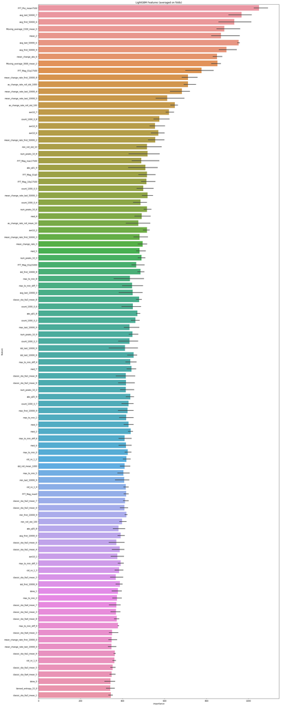

```python
%%time

lgb_params = {
    'num_leaves': 21,  # reducing to this helped with over fit
    'min_data_in_leaf': 20,
    'objective':'regression',
    'max_depth': 108,  # bogus, check lgb hard limit max depth, depth controlled by min_data_in_leaf
    'learning_rate': 0.05,
    "boosting": "gbdt",
    "feature_fraction": 0.91,
    "bagging_freq": 1,
    "bagging_fraction": 0.91,
    "bagging_seed": 42,
    "metric": 'mae',
    "lambda_l1": 0.1,
    "verbosity": -1,
    "random_state": 42
}

oof_lgb, prediction_lgb, feature_importance = train_model(scaled_train_X, scaled_test_X, train_y, kf,
                                                  params = lgb_params, model_type='lgb', plot_feature_importance=True)
```

另外，经过多次验证表明，测试loss比训练和验证loss都低，了能有两个结果：（1）欠拟合（这个可能性比较低）（2）数据量太少（这个很有可能，因为测试集只用13%做测试，也就是只有200多条测试数据）（3）测试集的outlier比训练集少很多。  
因此，总结如下：（1）Trust your CV （2）对数据做降噪处理

## XGBoost

用贝叶斯方法进行参数选择：

```python
# xgb_params = quick_hyperopt(scaled_train_X, train_y, package='xgb', num_evals=100)
# xgb_params
```

时间原因，最后未使用贝叶斯调参（耗时太久）：

```python
%%time

xgb_params = {
    'colsample_bytree': 0.67,
    'eval_metric': 'mae',
    'learning_rate': 0.02,
    'max_depth': 6,
    'reg_lambda': 1.0,
    'subsample': 0.9
}

oof_xgb, prediction_xgb = train_model(scaled_train_X, scaled_test_X, train_y, kf, params = xgb_params, model_type='xgb')
```

```
Fold 0:
Multiple eval metrics have been passed: 'valid-mae' will be used for early stopping.

Will train until valid-mae hasn't improved in 100 rounds.
Stopping. Best iteration:

Fold 1:
Multiple eval metrics have been passed: 'valid-mae' will be used for early stopping.

Will train until valid-mae hasn't improved in 100 rounds.
Stopping. Best iteration:

Fold 2:
Multiple eval metrics have been passed: 'valid-mae' will be used for early stopping.

Will train until valid-mae hasn't improved in 100 rounds.
Stopping. Best iteration:

Fold 3:
Multiple eval metrics have been passed: 'valid-mae' will be used for early stopping.

Will train until valid-mae hasn't improved in 100 rounds.
Stopping. Best iteration:

Fold 4:
Multiple eval metrics have been passed: 'valid-mae' will be used for early stopping.

Will train until valid-mae hasn't improved in 100 rounds.
Stopping. Best iteration:

Fold 5:
Multiple eval metrics have been passed: 'valid-mae' will be used for early stopping.

Will train until valid-mae hasn't improved in 100 rounds.
Stopping. Best iteration:

CV mean score: 2.05389, std score: 0.66263
CPU times: user 42min 46s, sys: 5.43 s, total: 42min 51s
Wall time: 21min 44s
```

## CatBoost

用贝叶斯方法进行参数选择：

```python
# cb_params = quick_hyperopt(scaled_train_X, train_y, package='cb', num_evals=100)
# cb_params
```

时间原因，最后未使用贝叶斯调参（耗时太久）：

```python
%%time

cb_params = {
    'objective': "MAE",
    'loss_function': 'MAE',
    'boosting_type': "Ordered"
}

oof_cb, prediction_cb = train_model(scaled_train_X, scaled_test_X, train_y, kf, params = cb_params, model_type='cb')
```

```
Fold 0:
Fold0 : train's l1: 0.58323, valid's l1: 1.28410
Fold 1:
Fold1 : train's l1: 0.59789, valid's l1: 1.27778
Fold 2:
Fold2 : train's l1: 0.59027, valid's l1: 1.29911
CV mean score: 1.28700, std score: 0.00894
CPU times: user 27min 25s, sys: 56min 16s, total: 1h 23min 42s
Wall time: 1h 16min 18s
```

## Neural Network

```python
%%time

oof_nn, prediction_nn = train_model(scaled_train_X, scaled_test_X, train_y, kf, model_type='nn')
```

[output not shown]

## SVR

用贝叶斯方法进行参数选择：

```python
# svr_params = quick_hyperopt(scaled_train_X, train_y, package='sklearn',num_evals=100)
# svr_params
```

```python
# %%time

svr_params = {'C': 15.844733356886566, 'gamma': 0.0011238961587171446, 'nu': 0.7631978191886737, 'tol': 0.1}
# model = NuSVR(**svr_params)
# oof_svr, prediction_svr = train_model(scaled_train_X, scaled_test_X, train_y, kf, model_type='sklearn', model=model)
```

针对以上5个模型训练出的结果，有两种方式进行模型融合：

## （1）平均法

| 榜单 | LB | PB |
| --- | --- | --- |
| 得分 | 1.378 | 2.523 |
| 最终排名 | 445 |  |

```python
submission['time_to_failure'] = (prediction_lgb + prediction_xgb + prediction_cb + prediction_nn) / 4
submission.to_csv('submission_averaging.csv', index=True)
```

## （2）结合法（stacking）

| 榜单 | LB | PB |
| --- | --- | --- |
| 得分 | 1.438 | 2.469 |
| 最终排名 | 111 |  |

```python
def stack_model():
    # 第一层：lgb xgb cb nn
    train_X = pd.DataFrame(index=range(oof_lgb.shape[0]))
    train_X['oof_lgb'] = oof_lgb
    train_X['oof_xgb'] = oof_xgb
    train_X['oof_cb'] = oof_cb
    train_X['oof_nn'] = oof_nn
    test_X = pd.DataFrame(index=range(prediction_lgb.shape[0]))
    test_X['prediction_lgb'] = prediction_lgb
    test_X['prediction_xgb'] = prediction_xgb
    test_X['prediction_cb'] = prediction_cb
    test_X['prediction_nn'] = prediction_nn

    # 第二层：SVR
    model = NuSVR(**svr_params)
    oof_svr, prediction_svr = train_model(train_X, test_X, train_y, kf, model_type='sklearn', model=model)
    submission['time_to_failure'] = prediction_svr
    submission.to_csv('submission_stacking.csv', index=True)

stack_model()
```

```
Fold 0:
Fold0 : train's l1: 0.90105, valid's l1: 0.89362
Fold 1:
Fold1 : train's l1: 0.89445, valid's l1: 0.90738
Fold 2:
Fold2 : train's l1: 0.89802, valid's l1: 0.90162
CV mean score: 0.90087, std score: 0.00564
```

# 参考kernel

1. [LANL Earthquake EDA and Prediction](https://www.kaggle.com/gpreda/lanl-earthquake-eda-and-prediction#Model)（以这个作为baseline）
2. [Earthquakes FE. More features and samples](https://www.kaggle.com/artgor/earthquakes-fe-more-features-and-samples)（从这里学到了模型融合）
3. [Parameter Tuning in One Function with Hyperopt](https://www.kaggle.com/bigironsphere/parameter-tuning-in-one-function-with-hyperopt)（贝叶斯方法进行参数最优化）
4. [Masters Final Project – Model; LB~1.392](https://www.kaggle.com/vettejeep/masters-final-project-model-lb-1-392)（1.证实了扩增数据量能带来很好的效果 2.将数据往0进行了平移，处理训练集和测试集均值不一致的问题）
5. [15 features, lgb, LB -> 1.483](https://www.kaggle.com/rafzy15/15-features-lgb-lb-1-483?scriptVersionId=13508931)（选取了一些时序特征）
6. [Masters Final Project: EDA](https://www.kaggle.com/vettejeep/masters-final-project-eda)（对频域的一些分析）
7. [LANL Master Final Prediction](https://www.kaggle.com/tocha4/lanl-master-s-approach)（提供神经网络和遗传算法的baseline）

# 赛后总结

## 第1名方案[1-Geomean NN and 6FeatLGBM](https://www.kaggle.com/dkaraflos/1-geomean-nn-and-6featlgbm-2-259-private-lb)

1. 去噪  
   用小波变换进行去噪，然后添加了随机噪声以增强鲁棒性
2. 特征提取 使用音频特征提取库librosa进行特征提取，只提取了几个特征：  
   （1）峰值点数量  
   （2）用size为50的窗口平滑后percentile20的数值  
   （3）4阶和18阶梅尔频率倒谱系数均值
3. 调整训练集  
   数据探索中发现训练集和验证集分布不一致，为此，先将训练集划分为16部分每一部分是一次地震的数据。然后计算一部分特征，根据这一部分特征来寻找训练集的子集（若干次地震），使得子集的这些特征与测试集的这些特征分布一致。这样，就认为找到了所有特征都和验证集一致的训练集子集，用这个子集作为训练集。
4. 交叉验证  
   普通的3折交叉验证（取更多折结果也差不多）
5. 模型 采用LGB、SVR和NN三个模型的均值。其中NN模型是一个多任务学习模型，除了学习mae，还学习是否小于0.5，以此预测数值特别小的ttf。

## 第2名方案[2nd place solution](https://www.kaggle.com/c/LANL-Earthquake-Prediction/discussion/94369#latest-547200)

根据[p4677](https://www.kaggle.com/c/LANL-Earthquake-Prediction/discussion/90664#latest-535844)选出train set的一部分作为private-set-like data，然后从private-set里选2000000个样本作为训练集（如果进行不重叠分割的话应该是2000个样本），不设置验证集，使用catboost进行训练。  
只用了32个特征，主要包括std, kurt, peaks(不同高度之上的), percentiles, trend, trend_error等特征。 作者表示特征的构建和选择很依赖直觉。

## 第三名方案[3rd place memo](https://www.kaggle.com/c/LANL-Earthquake-Prediction/discussion/94459#latest-549356)

根据[p4677](https://www.kaggle.com/c/LANL-Earthquake-Prediction/discussion/90664#latest-535844)对train set的label（'time_to_failure'）进行了调整，使得16个地震到来时间的峰值都是12.625，使用调整后的label进行训练。  
调整后即便是简易模型在PB上排名也很靠前。

## 第7名方案[7th solution, CPMP view](https://www.kaggle.com/c/LANL-Earthquake-Prediction/discussion/94407#latest-548305)

经过shake up后PB前十名中唯一在榜的

1. 交叉验证  
   先进行了16折交叉（16次地震），CV和LB还是不太符合。于是取出其中一份数据作为测试集，其他15份数据进行交叉验证，总共有15个模型，将15个模型在“测试集”上的结果作为CV指标，得到了很好的效果。
2. 数据采样  
   每隔50k个数据采样一次，采样长度为150k
3. 特征提取 使用音频特征提取库librosa提取了7个特征，然后造了4个不同信号百分数的方差的特征，以及1个二元特征以预示地震是否到来。
4. 异常点  
   声学数据峰值点和地震来临时间点不重合（有0.3s）的差距，将这0.3s的数据视为异常点。用一个二分类模型取预测这些点。
5. 模型  
   lgb，几乎没怎么调参
6. 模型融合  
   stacking：第一层用lgb、gam、knn、nn（各个模型尽量不同），第二层用lgb
7. 训练集分布调整  
   根据[p4677](https://www.kaggle.com/c/LANL-Earthquake-Prediction/discussion/90664#latest-535844)对train set的label（'time_to_failure'）进行了调整
8. 后处理  
   二分类模型预测的地震峰值点预测值设置为0.2

作者最主要的告诫：Trust your CV!